# CaseStudy2 Notebook

Jason Fields & Scott Payne

December 3, 2016

```r
knitr::opts_chunk$set(echo = TRUE)
```

# Documenting the code and package versions

```r
#library(fpp)
install.packages("tseries")
library(tseries)
```

## Question 1

Create the X matrix and print it from SAS, R, and Python.

SAS Matrix Input

proc IML;

X = {4 5 1 2, 1 0 3 5, 2 1 8 2};

print X;

R Matrix input

```r
 X <- matrix(c(4, 5, 1, 2, 1, 0, 3, 5, 2, 1, 8, 2),nrow = 3,ncol = 4,byrow = TRUE)
X
```

```
     [,1] [,2] [,3] [,4]
[1,]    4    5    1    2
[2,]    1    0    3    5
[3,]    2    1    8    2
```

Python Matrix input

```python
import numpy as np
X = np.matrix('4, 5, 1, 2; 1, 0, 3, 5; 2, 1, 8, 2')
print(X)
```

```
[[4 5 1 2]
 [1 0 3 5]
 [2 1 8 2]]
```

## Question 2

Please do the following with your assigned stock. Jason & Scott: GW Pharamceuticals (GWPH)  
* Download the data. * Calculate log returns. * Calculate volatility measure. * Calculate volatility over entire length of series for various three different decay factors. * Plot the results, overlaying the volatility curves on the data, just as was done in the S&P example.

Download the data

```r
stock_data<-get.hist.quote('GWPH',quote="Close")
```

```
time series starts 2013-05-01
```

```r
length(stock_data)
```

```
[1] 910
```

Calculate log returns.

```r
stock_log<-log(lag(stock_data))-log(stock_data)
length(stock_log)
```

```
[1] 909
```

Calculate volatility measure.

```r
stock_vol<-sd(stock_log)*sqrt(250)*100
print(stock_vol)
```

```
[1] 74.22491
```

Calculate volatility over entire length of series for various three different decay factors.

```r
## volatility
Vol <- function(d, logrets)
{
    var = 0
    lam = 0
    varlist <- c()
    for (r in logrets) {
        lam = lam*(1 - 1/d) + 1
    var = (1 - 1/lam)*var + (1/lam)*r^2
        varlist <- c(varlist, var)
    }
    sqrt(varlist)
}
```

Plot the results, overlaying the volatility curves on the data, just as was done in the S&P example.

```r
# Recreate Figure 6.12 in the text on page 155
volest <- Vol(10,stock_log)
volest2 <- Vol(30,stock_log)
volest3 <- Vol(100,stock_log)
plot(volest,type="l")
lines(volest2,type="l",col="red")
```

[figure not shown]

```r
lines(volest3, type = "l", col="blue")
```

## Question 3

The built-in data set called Orange in R is about the growth of orange trees. The Orange data frame has 3 columns of records of the growth of orange trees.

Variable description Tree : an ordered factor indicating the tree on which the measurement is made. The ordering is according to increasing maximum diameter. age : a numeric vector giving the age of the tree (days since 1968/12/31) circumference : a numeric vector of trunk circumferences (mm). This is probably “circumference at breast height”, a standard measurement in forestry.

load the data

```r
data("Orange")
Orange
```

|  | Tree | age | circumference |
| --- | --- | --- | --- |
| 1 | 1 | 118 | 30 |
| 2 | 1 | 484 | 58 |
| 3 | 1 | 664 | 87 |
| 4 | 1 | 1004 | 115 |
| 5 | 1 | 1231 | 120 |
| 6 | 1 | 1372 | 142 |
| 7 | 1 | 1582 | 145 |
| 8 | 2 | 118 | 33 |
| 9 | 2 | 484 | 69 |
| 10 | 2 | 664 | 111 |

[output cut: 25 more lines]

1. Calculate the mean and the median of the trunk circumferences for different size of the trees. (Tree)

```r
tree_mean<-aggregate(Orange$circumference, list(Orange$Tree), FUN=mean)
tree_mean
```

| Group.1 | x |
| --- | --- |
| 3 | 94.00000 |
| 1 | 99.57143 |
| 5 | 111.14286 |
| 2 | 135.28571 |
| 4 | 139.28571 |

```r
tree_median<-aggregate(Orange$circumference, list(Orange$Tree), FUN=median)
tree_median
```

| Group.1 | x |
| --- | --- |
| 3 | 108 |
| 1 | 115 |
| 5 | 125 |
| 2 | 156 |
| 4 | 167 |

2. Make a scatter plot of the trunk circumferences against the age of the tree. Use different plotting symbols for different size of trees.

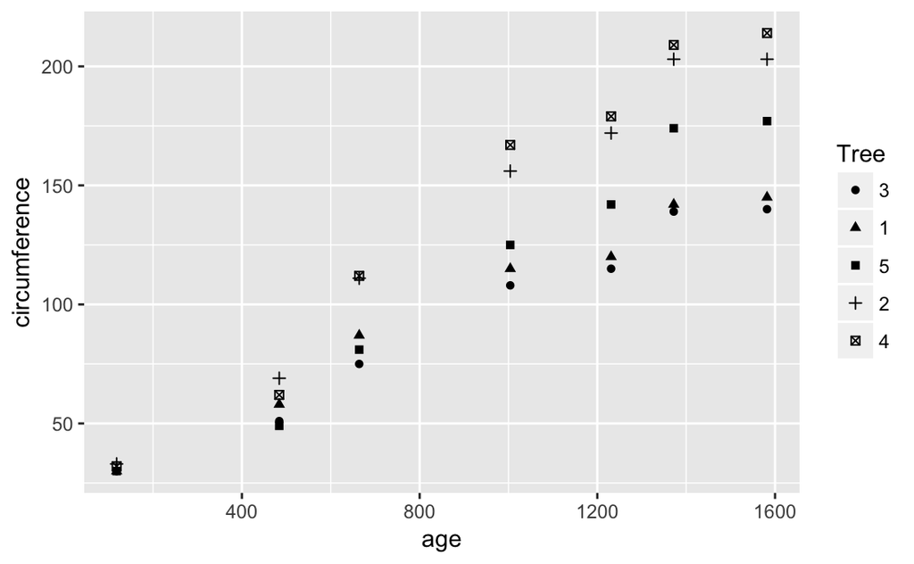

```r
library(ggplot2)
ggplot(Orange, aes(y=circumference, x=age, shape=Tree)) +
    geom_point()
```

3. Display the trunk circumferences on a comparative boxplot against tree. Be sure you order the boxplots in the increasing order of maximum diameter.

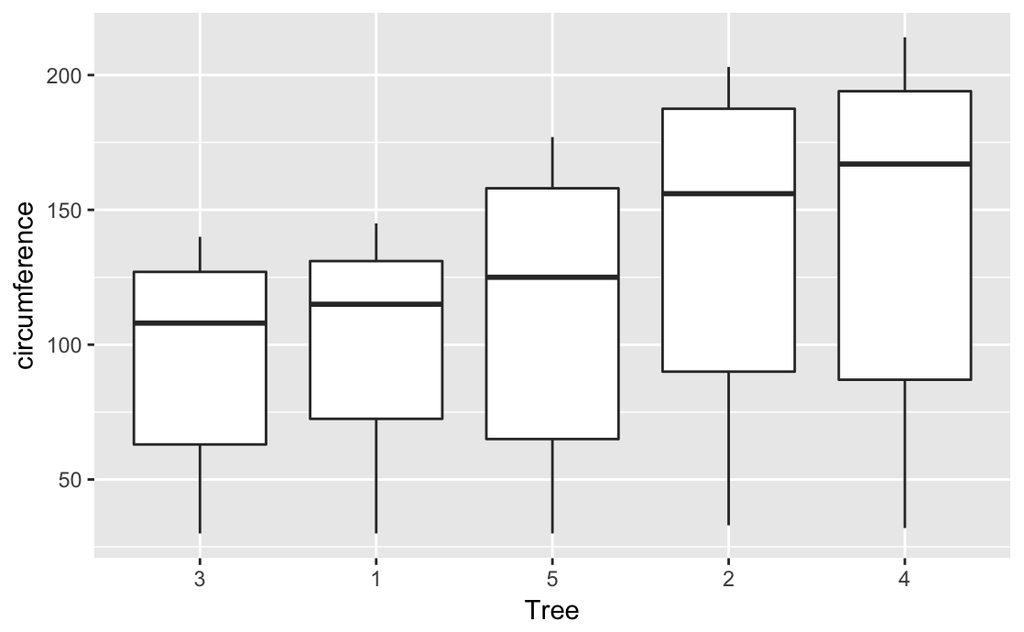

```r
ggplot(Orange, aes(y=circumference, x=Tree)) +
    geom_boxplot()
```

## Question 4

Download “Temp” data set (check your SMU email)

```r
temp<-read.csv('Temp.csv', header = TRUE,
         dec = ".", fill = TRUE )
head(temp)
```

|  | Date | Monthly.AverageTemp | Monthly.AverageTemp.Uncertainty | Country |
| --- | --- | --- | --- | --- |
| 1 | 1838-04-01 | 13.008 | 2.586 | Afghanistan |
| 2 | 1838-05-01 | NA | NA | Afghanistan |
| 3 | 1838-06-01 | 23.950 | 2.510 | Afghanistan |
| 4 | 1838-07-01 | 26.877 | 2.883 | Afghanistan |
| 5 | 1838-08-01 | 24.938 | 2.992 | Afghanistan |
| 6 | 1838-09-01 | 18.981 | 2.538 | Afghanistan |

```r
summary(temp)
```

```
       Date        Monthly.AverageTemp
 1/1/1951:   242   Min.   :-37.66
 1/1/1952:   242   1st Qu.: 10.16
 1/1/1953:   242   Median : 21.00
 1/1/1954:   242   Mean   : 17.26
 1/1/1955:   242   3rd Qu.: 25.83
 1/1/1956:   242   Max.   : 38.84
 (Other) :572771   NA's   :32578
 Monthly.AverageTemp.Uncertainty
 Min.   : 0.05
 1st Qu.: 0.32
 Median : 0.57
 Mean   : 1.01
 3rd Qu.: 1.20
 Max.   :15.00
 NA's   :31839
                   Country
 Albania               :  3239
 Andorra               :  3239
 Austria               :  3239
 Belarus               :  3239
 Belgium               :  3239
 Bosnia And Herzegovina:  3239
 (Other)               :554789
```

1. Find the difference between the maximum and the minimum monthly average temperatures for each country and report/visualize top 20 countries with the maximum differences for the period since 1900.

```r
high.temp.variation <- diff.temp[1:20,diff.temp$Country]
```

```
Error in `[.data.frame`(diff.temp, 1:20, diff.temp$Country) :
  undefined columns selected
```

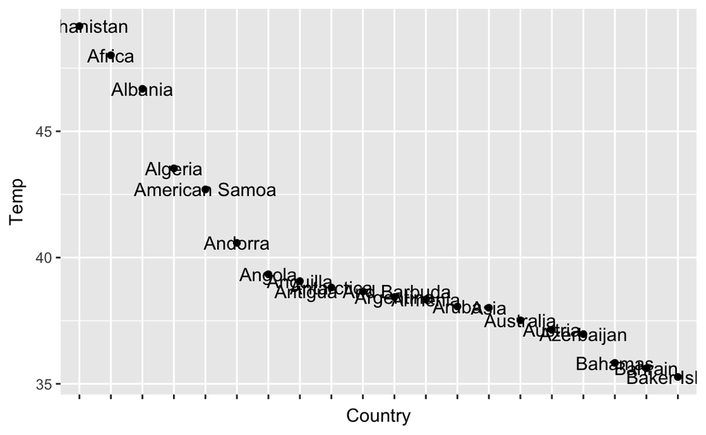

```r
xspace<-seq(1,20,by=1)
#makeshift spacing to see Temps, need to add country labels
# ggplot(high.temp.variation, aes(xspace,Temp)) + geom_point()+ xlab("Country") + geom_text(aes(label=high.temp.variation$Country))
#failed country vs temp bar plot
plot_q4_i<-ggplot(high.temp.variation, aes(Country,Temp, labels(high.temp.variation$Country))) + geom_point(stat="identity")+ xlab("Country") + theme(axis.text.x=element_blank()) + geom_text(aes(label=high.temp.variation$Country))
plot_q4_i
```

2. ```
   Select a subset of data called “UStemp” where US land temperatures from 01/01/1990 in Temp data. Use UStemp dataset to answer the followings.
   ```

```r
UStemp <- temp[temp$Country == 'United States',]
head(temp)
```

[output not shown]

```r
summary(temp)
```

```
      Date                     Monthly.AverageTemp
 Min.   :1900-01-01 00:00:00   Min.   :-37.18
 1st Qu.:1928-08-01 00:00:00   1st Qu.: 13.32
 Median :1957-03-01 00:00:00   Median : 23.26
 Mean   :1957-01-06 21:20:44   Mean   : 18.89
 3rd Qu.:1985-06-01 00:00:00   3rd Qu.: 26.36
 Max.   :2013-09-01 00:00:00   Max.   : 38.84
                               NA's   :1049
 Monthly.AverageTemp.Uncertainty   Country
 Min.   :0.0520                  Length:328503
 1st Qu.:0.2590                  Class :character
 Median :0.3650                  Mode  :character
 Mean   :0.4476
 3rd Qu.:0.5390
 Max.   :8.4250
 NA's   :310
```

1. Create a new column to display the monthly average land temperatures in Fahrenheit (°F).

```r
library(weathermetrics)
UStemp$Monthly.AverageTempF <- convert_temperature(UStemp$Monthly.AverageTemp, old_metric = "celsius", new_metric = "fahrenheit")
```

2. Calculate average land temperature by year and plot it. The original file has the average land temperature by month.

```r
UStemp$Year <- format(UStemp$Date,format="%Y")
Yearly <- aggregate(UStemp$Monthly.AverageTempF ~ Year , UStemp, mean, na.rm = T)
```

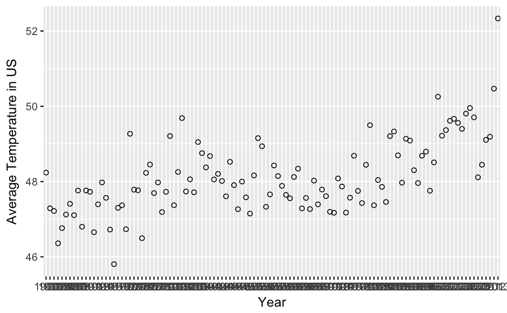

```r
ggplot(Yearly, aes(x=Year, y=`UStemp$Monthly.AverageTempF`)) +
geom_point(shape=1) + xlab("Year") + ylab("Average Temperature in US")
```

```r
Yearly$two.year <- diff(c(0,Yearly$`UStemp$Monthly.AverageTempF`))
Yearly$two.year
```

```
  [1] 48.23833333 -0.94916667 -0.07083333 -0.85916667
  [5]  0.40333333  0.36250000  0.28333333 -0.30166667
  [9]  0.65416667 -0.96166667  0.96416667 -0.03500000
 [13] -1.07416667  0.74083333  0.58166667 -0.40833333
 [17] -0.84416667 -0.92000000  1.49750000  0.06750000
 [21] -0.63666667  2.53833333 -1.48750000 -0.01500000
 [25] -1.27333333  1.73583333  0.22166667 -0.75833333
 [29]  0.28250000 -0.78750000  0.53833333  1.48250000
 [33] -1.83916667  0.88416667  1.43250000 -1.95166667
 [37]  0.32416667 -0.34416667  1.33416667 -0.29500000
 [41] -0.37916667  0.30166667 -0.62166667  0.14833333
 [45] -0.18833333 -0.40750000  0.91583333 -0.61916667
 [49] -0.63833333  0.73333333 -0.41916667 -0.43166667
 [53]  1.01416667  0.99083333 -0.21583333 -1.60916667
 [57]  0.33000000  0.76833333 -0.28166667 -0.26000000
 [61] -0.24000000 -0.09083333  0.56750000  0.22000000
 [65] -1.05583333  0.27833333 -0.29500000  0.75416667
 [69] -0.62916667  0.39333333 -0.17750000 -0.41416667
 [73] -0.02583333  0.91166667 -0.21416667 -0.69333333
 [77]  0.39666667  1.11416667 -0.93416667 -0.32333333
 [81]  1.01666667  1.05333333 -2.12833333  0.67250000
 [85] -0.18250000 -0.40333333  1.75083333  0.12250000
 [89] -0.63333333 -0.72583333  1.16833333 -0.05083333
 [93] -0.78666667 -0.34166667  0.72666667  0.10833333
 [97] -1.03833333  0.75333333  1.74500000 -1.03583333
[101]  0.14833333  0.24666667  0.05333333 -0.10750000
[105] -0.15916667  0.40583333  0.14750000 -0.24750000
[109] -1.59333333  0.33250000  0.66250000  0.08250000
[113]  1.27833333  1.86527778
```

3. Download “CityTemp” data set (check your SMU email). Find the difference between the maximum and the minimum temperatures for each major city and report/visualize top 20 cities with maximum differences for the period since 1900.

Align date formats and subset for after the year 1900

Reshape the data to do analysis

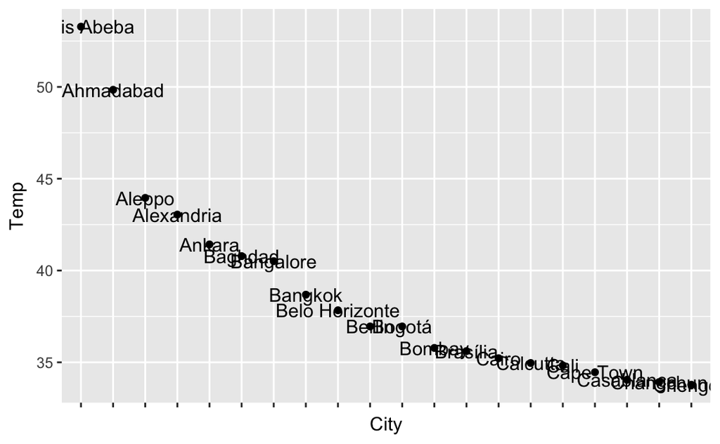

```r
#ggplot(high.CityTemp.variation, aes(x,y=City)) + geom_bar()
# qplot(x, xspace, data=high.CityTemp.variation,geom="point", xlab="City", ylab="Temperature")
plot_q4_iii<-ggplot(high.CityTemp.variation, aes(City,x, labels(high.CityTemp.variation.variation$City))) + geom_point(stat="identity")+ xlab("City") + ylab("Temp") +  theme(axis.text.x=element_blank()) + geom_text(aes(label=high.CityTemp.variation$City))
plot_q4_iii
```

4. ```
   Compare the two graphs in (i) and (iii)  and comment it.
   ```

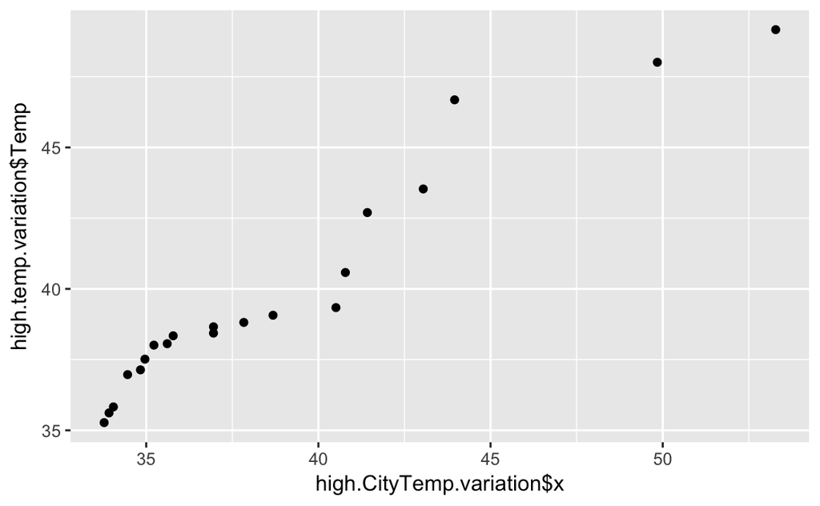

```r
dat<-data.frame(high.temp.variation,high.CityTemp.variation)
ggplot(dat,aes(y=high.temp.variation$Temp,x=high.CityTemp.variation$x))+geom_point()
```

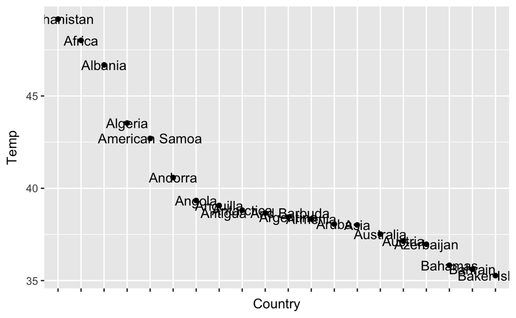

```r
plot_q4_i
```

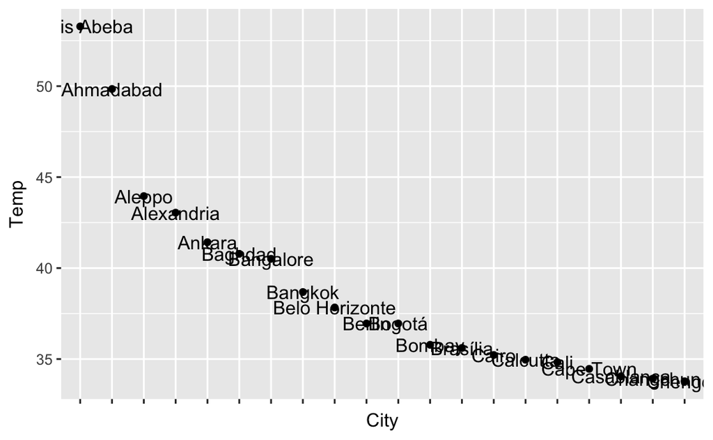

```r
plot_q4_iii
```

The two charts show very similar trends between cities and countries.